# PCA

```python
# See the value of multiple statements at once
#output for all commands in python jupyter notebook

from IPython.core.interactiveshell import InteractiveShell
InteractiveShell.ast_node_interactivity = "all"

import warnings
warnings.filterwarnings('ignore')

# Importing the packages

import numpy as np
import pandas as pd
import matplotlib.pyplot as plt
import seaborn as sns
import time
import random
from sklearn.decomposition import PCA

%matplotlib inline
```

### Data Description

The dataset describes diagnosing of cardiac Single Proton Emission Computed Tomography (SPECT) images. Each of the patients is classified into two categories: normal and abnormal. The database of 267 SPECT image sets (patients) was processed to extract features that summarize the original SPECT images. As a result, 44 continuous feature pattern was created for each patient.

1. OVERALL_DIAGNOSIS: 0,1 (class attribute, binary)
2. F1R: continuous (count in ROI (region of interest) 1 in rest)
3. F1S: continuous (count in ROI 1 in stress)
4. F2R: continuous (count in ROI 2 in rest)
5. F2S: continuous (count in ROI 2 in stress)
6. F3R: continuous (count in ROI 3 in rest)
7. F3S: continuous (count in ROI 3 in stress)
8. F4R: continuous (count in ROI 4 in rest)
9. F4S: continuous (count in ROI 4 in stress)
10. F5R: continuous (count in ROI 5 in rest)
11. F5S: continuous (count in ROI 5 in stress)
12. F6R: continuous (count in ROI 6 in rest)
13. F6S: continuous (count in ROI 6 in stress)
14. F7R: continuous (count in ROI 7 in rest)
15. F7S: continuous (count in ROI 7 in stress)
16. F8R: continuous (count in ROI 8 in rest)
17. F8S: continuous (count in ROI 8 in stress)
18. F9R: continuous (count in ROI 9 in rest)
19. F9S: continuous (count in ROI 9 in stress)
20. F10R: continuous (count in ROI 10 in rest)
21. F10S: continuous (count in ROI 10 in stress)
22. F11R: continuous (count in ROI 11 in rest)
23. F11S: continuous (count in ROI 11 in stress)
24. F12R: continuous (count in ROI 12 in rest)
25. F12S: continuous (count in ROI 12 in stress)
26. F13R: continuous (count in ROI 13 in rest)
27. F13S: continuous (count in ROI 13 in stress)
28. F14R: continuous (count in ROI 14 in rest)
29. F14S: continuous (count in ROI 14 in stress)
30. F15R: continuous (count in ROI 15 in rest)
31. F15S: continuous (count in ROI 15 in stress)
32. F16R: continuous (count in ROI 16 in rest)
33. F16S: continuous (count in ROI 16 in stress)
34. F17R: continuous (count in ROI 17 in rest)
35. F17S: continuous (count in ROI 17 in stress)
36. F18R: continuous (count in ROI 18 in rest)
37. F18S: continuous (count in ROI 18 in stress)
38. F19R: continuous (count in ROI 19 in rest)
39. F19S: continuous (count in ROI 19 in stress)
40. F20R: continuous (count in ROI 20 in rest)
41. F20S: continuous (count in ROI 20 in stress)
42. F21R: continuous (count in ROI 21 in rest)
43. F21S: continuous (count in ROI 21 in stress)
44. F22R: continuous (count in ROI 22 in rest)
45. F22S: continuous (count in ROI 22 in stress)

    **Objective**

    Our goal is to predict whether the SPECT images are normal or not.

    Dataset is divided into:
    - training data ("SPECT.train" 80 instances) -> https://query.data.world/s/ksxft7lhmbxpihskwsngwhpuul6lye
    - testing data ("SPECT.test" 187 instances) -> https://query.data.world/s/cuqtpuoewpxysusrt5z4igihjah4xo

```python
col_names = ['target']


for i in range(1,23):
    col1 = 'F' + str(i) + 'R'
    col2 = 'F' + str(i) + 'S'
    col_names.append(col1)
    col_names.append(col2)

print(col_names)
```

[output not shown]

```python
# Loading the train data

url = 'https://query.data.world/s/ksxft7lhmbxpihskwsngwhpuul6lye'

SPECT_train = pd.read_csv(url,sep=',',names=col_names)
```

```python
SPECT_train.shape
```

```
(80, 45)
```

```python
SPECT_train
```

|  | target | F1R | F1S | F2R | F2S | F3R | F3S | F4R | F4S | F5R | ... | F18R | F18S | F19R | F19S | F20R | F20S | F21R | F21S | F22R | F22S |
| --- | --- | --- | --- | --- | --- | --- | --- | --- | --- | --- | --- | --- | --- | --- | --- | --- | --- | --- | --- | --- | --- |
| 0 | 1 | 59 | 52 | 70 | 67 | 73 | 66 | 72 | 61 | 58 | ... | 66 | 56 | 62 | 56 | 72 | 62 | 74 | 74 | 64 | 67 |
| 1 | 1 | 72 | 62 | 69 | 67 | 78 | 82 | 74 | 65 | 69 | ... | 65 | 71 | 63 | 60 | 69 | 73 | 67 | 71 | 56 | 58 |
| 2 | 1 | 71 | 62 | 70 | 64 | 67 | 64 | 79 | 65 | 70 | ... | 73 | 70 | 66 | 65 | 64 | 55 | 61 | 41 | 51 | 46 |
| 3 | 1 | 69 | 71 | 70 | 78 | 61 | 63 | 67 | 65 | 59 | ... | 61 | 61 | 66 | 65 | 72 | 73 | 68 | 68 | 59 | 63 |
| 4 | 1 | 70 | 66 | 61 | 66 | 61 | 58 | 69 | 69 | 72 | ... | 67 | 69 | 70 | 66 | 70 | 64 | 60 | 55 | 49 | 41 |
| ... | ... | ... | ... | ... | ... | ... | ... | ... | ... | ... | ... | ... | ... | ... | ... | ... | ... | ... | ... | ... | ... |
| 75 | 0 | 70 | 75 | 72 | 72 | 67 | 71 | 71 | 78 | 63 | ... | 66 | 67 | 68 | 70 | 70 | 71 | 64 | 67 | 56 | 54 |
| 76 | 0 | 59 | 57 | 67 | 71 | 66 | 68 | 68 | 70 | 56 | ... | 62 | 64 | 56 | 53 | 71 | 68 | 64 | 63 | 56 | 56 |
| 77 | 0 | 67 | 64 | 73 | 75 | 77 | 77 | 74 | 70 | 65 | ... | 61 | 64 | 65 | 60 | 68 | 75 | 74 | 80 | 67 | 68 |
| 78 | 0 | 68 | 65 | 72 | 72 | 47 | 74 | 76 | 74 | 67 | ... | 64 | 69 | 71 | 73 | 73 | 75 | 68 | 56 | 58 | 44 |
| 79 | 0 | 66 | 54 | 69 | 66 | 69 | 69 | 75 | 72 | 63 | ... | 69 | 65 | 65 | 64 | 67 | 69 | 71 | 68 | 59 | 59 |

80 rows × 45 columns

```python
# Loading the test data

url = 'https://query.data.world/s/cuqtpuoewpxysusrt5z4igihjah4xo'

SPECT_test = pd.read_csv(url,sep=',',names=col_names)
```

```python
SPECT_test.shape
```

```
(187, 45)
```

```python
x = SPECT_train.drop('target', axis = 1)
y = SPECT_train['target']
```

# PCA

### Standardization data for PCA

In PCA, we should standardize the variables before applying PCA because it will give more emphasis to those variables having higher variances than to those variables with very low variances while identifying the right principle component.

Also standardizing is important in PCA since it is a variance maximizing technique. It projects your original data onto directions which maximize the variance.

By doing so, all the features contribute to the variance explanation.

Most of the distribution of columns follow normal distribution. Hence we can scale them using Standard Scaler to preprocess the data.

Standard Scaler standardize features by removing the mean and scaling to unit variance.
Each value is reduced using the following formula $$ z = \frac {x - \mu}{\sigma} $$ Where x is the value,
$\mu$ is the mean of that columns,
$\sigma$ is the standard deviation of that columns.

```python
# Scaling the Train and Test data

#import
from sklearn.preprocessing import StandardScaler

# Initialize
scaler=StandardScaler()

#Apply
SPECT_train_std = scaler.fit_transform(SPECT_train.drop('target',axis = 1))
SPECT_test_std = scaler.fit_transform(SPECT_test.drop('target',axis = 1))
```

```python
SPECT_train_std.shape
```

```
(80, 44)
```

```python
pd.DataFrame(SPECT_train_std)
```

|  | 0 | 1 | 2 | 3 | 4 | 5 | 6 | 7 | 8 | 9 | ... | 34 | 35 | 36 | 37 | 38 | 39 | 40 | 41 | 42 | 43 |
| --- | --- | --- | --- | --- | --- | --- | --- | --- | --- | --- | --- | --- | --- | --- | --- | --- | --- | --- | --- | --- | --- |
| 0 | -1.735923 | -2.273103 | 0.076727 | -0.612366 | 0.949762 | -0.256404 | -0.018453 | -1.828787 | -0.862193 | -1.552505 | ... | 0.143124 | -1.156300 | -0.472465 | -0.960396 | 0.330209 | -0.751854 | 0.725664 | 0.789390 | 0.749152 | 0.990166 |
| 1 | 0.602626 | -0.811300 | -0.093778 | -0.612366 | 1.754644 | 2.174689 | 0.473624 | -1.124561 | 0.628435 | -0.123421 | ... | -0.033029 | 0.845951 | -0.341679 | -0.534145 | -0.056377 | 0.537876 | 0.062741 | 0.523303 | 0.002334 | 0.242871 |
| 2 | 0.422738 | -0.811300 | 0.076727 | -1.089534 | -0.016098 | -0.560291 | 1.703817 | -1.124561 | 0.763947 | 0.656079 | ... | 1.376188 | 0.712468 | 0.050680 | -0.001332 | -0.700688 | -1.572592 | -0.505479 | -2.137562 | -0.464427 | -0.753522 |
| 3 | 0.062961 | 0.504322 | 0.076727 | 1.137251 | -0.981957 | -0.712234 | -1.248646 | -1.124561 | -0.726681 | -0.643088 | ... | -0.737637 | -0.488883 | 0.050680 | -0.001332 | 0.330209 | 0.537876 | 0.157444 | 0.257217 | 0.282391 | 0.658035 |
| 4 | 0.242849 | -0.226579 | -1.457816 | -0.771422 | -0.981957 | -1.471951 | -0.756569 | -0.420335 | 1.034971 | 0.526163 | ... | 0.319276 | 0.578984 | 0.573824 | 0.105231 | 0.072485 | -0.517358 | -0.600182 | -0.895825 | -0.651132 | -1.168686 |
| ... | ... | ... | ... | ... | ... | ... | ... | ... | ... | ... | ... | ... | ... | ... | ... | ... | ... | ... | ... | ... | ... |
| 75 | 0.242849 | 1.089043 | 0.417737 | 0.182915 | -0.016098 | 0.503312 | -0.264491 | 1.164174 | -0.184635 | 0.396246 | ... | 0.143124 | 0.312017 | 0.312252 | 0.531481 | 0.072485 | 0.303380 | -0.221369 | 0.168521 | 0.002334 | -0.089260 |
| 76 | -1.735923 | -1.542202 | -0.434787 | 0.023858 | -0.177074 | 0.047482 | -1.002607 | -0.244278 | -1.133216 | -0.253338 | ... | -0.561485 | -0.088433 | -1.257182 | -1.280083 | 0.201347 | -0.048365 | -0.221369 | -0.186261 | 0.002334 | 0.076805 |
| 77 | -0.296816 | -0.518940 | 0.588241 | 0.660083 | 1.593668 | 1.414972 | 0.473624 | -0.244278 | 0.086389 | -0.253338 | ... | -0.737637 | -0.088433 | -0.080107 | -0.534145 | -0.185239 | 0.772373 | 0.725664 | 1.321563 | 1.029209 | 1.073199 |
| 78 | -0.116927 | -0.372760 | 0.417737 | 0.182915 | -3.235629 | 0.959142 | 0.965701 | 0.459948 | 0.357412 | 0.266329 | ... | -0.209181 | 0.578984 | 0.704611 | 0.851169 | 0.459072 | 0.772373 | 0.157444 | -0.807129 | 0.189038 | -0.919588 |
| 79 | -0.476704 | -1.980742 | -0.093778 | -0.771422 | 0.305855 | 0.199426 | 0.719663 | 0.107835 | -0.184635 | -0.253338 | ... | 0.671580 | 0.045051 | -0.080107 | -0.107895 | -0.314102 | 0.068883 | 0.441554 | 0.257217 | 0.282391 | 0.325904 |

80 rows × 44 columns

```python
SPECT_test_std.shape
```

```
(187, 44)
```

```python
# Fitting the PCA on the data

from sklearn.decomposition import PCA
pca = PCA()
pca.fit(SPECT_train_std)
```

```
PCA(copy=True, iterated_power='auto', n_components=None, random_state=None,
    svd_solver='auto', tol=0.0, whiten=False)
```

```python
#The amount of variance that each PC explains
var= pca.explained_variance_ratio_
var
```

```
array([2.72647870e-01, 1.43817724e-01, 9.87573709e-02, 6.35283757e-02,
       4.83470503e-02, 4.54933491e-02, 4.20826098e-02, 3.27171437e-02,
       2.94722683e-02, 2.75515814e-02, 2.38467426e-02, 2.15002047e-02,
       1.59102279e-02, 1.52823531e-02, 1.25211431e-02, 1.19227275e-02,
       9.91424687e-03, 9.25633812e-03, 8.91297630e-03, 8.32134329e-03,
       7.45915078e-03, 6.11594282e-03, 5.46761244e-03, 5.10864460e-03,
       4.13833882e-03, 3.95756803e-03, 3.59277182e-03, 3.02555215e-03,
       2.72615975e-03, 2.44202280e-03, 2.27127841e-03, 1.96445457e-03,
       1.78778562e-03, 1.42097804e-03, 1.23824870e-03, 1.18104511e-03,
       9.05851337e-04, 8.28166977e-04, 6.70855885e-04, 5.66709805e-04,
       4.68058352e-04, 4.02830371e-04, 2.58601868e-04, 1.97723608e-04])
```

```python
np.round(var,decimals=3)*100
```

```
array([27.3, 14.4,  9.9,  6.4,  4.8,  4.5,  4.2,  3.3,  2.9,  2.8,  2.4,
        2.2,  1.6,  1.5,  1.3,  1.2,  1. ,  0.9,  0.9,  0.8,  0.7,  0.6,
        0.5,  0.5,  0.4,  0.4,  0.4,  0.3,  0.3,  0.2,  0.2,  0.2,  0.2,
        0.1,  0.1,  0.1,  0.1,  0.1,  0.1,  0.1,  0. ,  0. ,  0. ,  0. ])
```

```python
np.sum(np.round(pca.explained_variance_ratio_, decimals=4)*100)
```

```
100.0
```

```python
#Cumulative Variance explains
var1=np.cumsum(np.round(pca.explained_variance_ratio_, decimals=4)*100)
var1
```

```
array([ 27.26,  41.64,  51.52,  57.87,  62.7 ,  67.25,  71.46,  74.73,
        77.68,  80.44,  82.82,  84.97,  86.56,  88.09,  89.34,  90.53,
        91.52,  92.45,  93.34,  94.17,  94.92,  95.53,  96.08,  96.59,
        97.  ,  97.4 ,  97.76,  98.06,  98.33,  98.57,  98.8 ,  99.  ,
        99.18,  99.32,  99.44,  99.56,  99.65,  99.73,  99.8 ,  99.86,
        99.91,  99.95,  99.98, 100.  ])
```

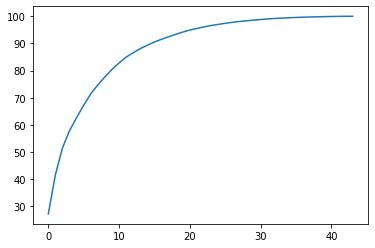

```python
# Scree Plot - An Approach to Choosing the Number of Components
plt.plot(var1);
```

```python
pca.explained_variance_ratio_[:22].sum()
```

```
0.9553787409542429
```

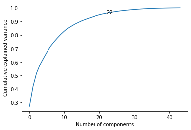

```python
# Plotting relation between components and variance

plt.plot(np.cumsum(pca.explained_variance_ratio_))
plt.xlabel('Number of components')
plt.ylabel('Cumulative explained variance')
plt.annotate('22',xy=(22, .955));
```

```python
# consider first 22 components as they are explaining the 95% of variation in the data

pca_model = PCA(n_components=22)
```

```python
train_pca = pca_model.fit_transform(SPECT_train_std)
#test_pca = pca_model.fit_transform(SPECT_test.drop('target',axis = 1))
```

```python
pd.DataFrame(train_pca).head()
```

|  | 0 | 1 | 2 | 3 | 4 | 5 | 6 | 7 | 8 | 9 | ... | 12 | 13 | 14 | 15 | 16 | 17 | 18 | 19 | 20 | 21 |
| --- | --- | --- | --- | --- | --- | --- | --- | --- | --- | --- | --- | --- | --- | --- | --- | --- | --- | --- | --- | --- | --- |
| 0 | 1.157126 | 4.040948 | -0.852346 | 2.621394 | -1.110057 | 1.017941 | 0.805768 | -0.855329 | 0.305797 | -0.033704 | ... | 0.439865 | -1.053750 | -0.527751 | -0.434960 | 0.220270 | -0.396163 | -0.199602 | -1.161904 | 0.248036 | -0.083836 |
| 1 | -2.135618 | 1.422864 | 0.855580 | -0.830391 | -1.599911 | 0.955005 | -1.055004 | 0.545468 | -0.233071 | 0.954349 | ... | 0.046772 | 0.129841 | -0.169665 | 0.651712 | 1.004370 | -1.558601 | -0.238564 | -0.027629 | 0.018395 | 0.170996 |
| 2 | 0.949090 | -4.559604 | 2.626745 | 1.442806 | -2.103780 | -0.046103 | -0.516982 | -0.480451 | 0.049417 | -1.196826 | ... | 0.790659 | 0.533649 | 0.791242 | -1.103201 | -0.078213 | 0.423179 | -0.600161 | -0.563479 | 0.878227 | 0.739751 |
| 3 | 0.789692 | 2.146945 | -1.430832 | 0.826511 | 1.909100 | 1.102112 | 0.992398 | -1.011095 | 1.430149 | -0.062975 | ... | 0.468256 | 0.129645 | -0.361578 | 0.473142 | -0.287331 | 0.188807 | 0.594486 | -0.589217 | -0.104000 | 0.239805 |
| 4 | 1.615643 | -2.014818 | 0.396867 | 1.530897 | -0.662015 | -2.562761 | 3.295478 | 1.885495 | -0.914902 | 2.009353 | ... | -0.736354 | -0.882936 | 0.065571 | -1.169634 | 0.229341 | -0.227950 | -0.660830 | -0.132242 | -0.313483 | -0.213269 |

5 rows × 22 columns

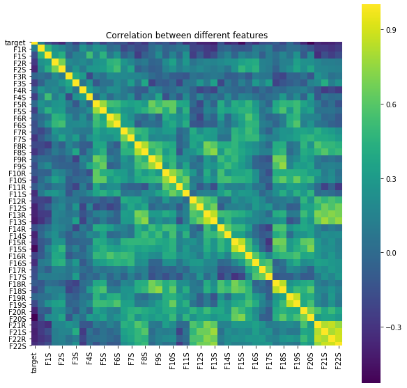

```python
plt.figure(figsize=(10,10))
correlation = pd.DataFrame(SPECT_train).corr()
sns.heatmap(correlation, vmax=1, square=True,cmap='viridis')
plt.title('Correlation between different features');
```

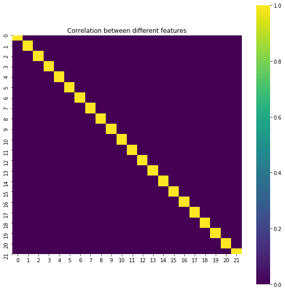

```python
# correlation between the variables after transforming the data with PCA is 0,
# this is the Orthogonal property (variables are statistically independent). With Zero correlation

plt.figure(figsize=(10,10))
correlation = pd.DataFrame(train_pca).corr()
sns.heatmap(correlation, vmax=1, square=True,cmap='viridis')
plt.title('Correlation between different features');
```

## Build Logistic regression with PCs

```python
# train a logistic regression model on the training set
from sklearn.linear_model import LogisticRegression

# instantiate model
pca_logreg = LogisticRegression()

start = time.time()
# fit model
pca_logreg.fit(train_pca, SPECT_train['target'])
end = time.time()
training_time = end-start
print("Time required to train a Logistic Regression after PCA: ", training_time)
```

```
LogisticRegression(C=1.0, class_weight=None, dual=False, fit_intercept=True,
                   intercept_scaling=1, l1_ratio=None, max_iter=100,
                   multi_class='warn', n_jobs=None, penalty='l2',
                   random_state=None, solver='warn', tol=0.0001, verbose=0,
                   warm_start=False)
```

```
Time required to train a Logistic Regression after PCA:  0.005056858062744141
```

```python
# make class predictions for the testing set
SPECT_test_std_pca_pred = pca_logreg.predict(test_pca)
```

```python
print(accuracy_score(SPECT_test['target'],SPECT_test_std_pca_pred))
```

```
0.42780748663101603
```